# Data analysis : test of hybrid immune vigor in response to parasite infection

Alice Balard

2018-10-08

## Installation

```r
library(parasiteLoad)
library(bbmle)
require(optimx) # for bbmle it needs to be required(?)
library(ggplot2)
library(MASS)
```

## Prepare dataset for each analysis

```r
# add 1 for worms/oocysts count!!
WATWMdata$`Aspiculuris.Syphacia+1` <- WATWMdata$Aspiculuris.Syphacia + 1
BALdata$`Aspiculuris.Syphacia+1` <- BALdata$Aspiculuris_Syphacia + 1
BALdata$`OPG+1` <- BALdata$OPG + 1

# and select variables for each analysis
qpcr_data <- BALdata[!is.na(BALdata$HI) &
                       !is.na(BALdata$Sex) &
                       !is.na(BALdata$delta_ct_MminusEAllPos), ]

flotation_data <- BALdata[!is.na(BALdata$`OPG+1`) &
                            !is.na(BALdata$HI) &
                            !is.na(BALdata$Sex), ]


pinworms_data <- BALdata[!is.na(BALdata$`Aspiculuris.Syphacia+1`) &
                           !is.na(BALdata$HI) &
                           !is.na(BALdata$Sex),]

body_data <- BALdata[!is.na(BALdata$Body_weight) &
                       !is.na(BALdata$Body_length) &
                       !is.na(BALdata$HI) &
                       !is.na(BALdata$Sex) &
                       !is.na(BALdata$qPCRstatus) ,]

WATWMdata <- WATWMdata[!is.na(WATWMdata$`Aspiculuris.Syphacia+1`) &
                         !is.na(WATWMdata$HI) &
                         !is.na(WATWMdata$Sex), ]

# all worms together for comparison
d1 <- WATWMdata[c("Sex", "Aspiculuris.Syphacia+1", "HI")]
d2 <- pinworms_data[c("Sex", "Aspiculuris.Syphacia+1", "HI")]
d1$batch <- "WATWM"
d2$batch <- "JENNY"
allWorms <- rbind(d1,d2)
allWorms$batch <- as.factor(allWorms$batch)
```

## Part 1. qpcr results, 4 hypotheses, difference between sexes

### Choose a correct distribution for our data

Let’s compute some fits…

```r
qpcr_data[qpcr_data$delta_ct_MminusEAllPos > 0,"delta_ct_MminusEAllPos"]
```

```
#>  [1]  4.7300000  3.4433333  2.8700000  2.7833333  2.4200000  1.4066667
#>  [7]  3.8500000  1.1600000  1.4300000  7.9000000  9.7500000  4.6466667
#> [13]  2.6600000  5.9433333  6.9300000  4.9233333  3.5500000  2.2300000
#> [19]  1.8733333  7.6066667  9.3900000  2.7466667  0.3133333  1.6500000
#> [25]  0.1666667  6.1300000  2.1033333  0.2266667  1.9233333  8.3166667
#> [31]  0.1800000  2.6250000  3.6200000  8.7000000  5.0800000  4.3450000
#> [37]  4.0600000  4.2750000  4.4750000  3.3900000  0.4500000  0.7900000
#> [43]  1.5650000  0.2700000  1.2633333  2.9300000  2.1800000  1.9400000
#> [49]  1.3950000  0.0550000  0.1000000  0.2100000  2.6450000  4.0400000
#> [55]  2.1500000  0.4450000  3.8700000  2.5050000  0.0150000  1.3200000
#> [61]  0.0650000  3.8250000  1.8300000  1.4700000 10.0200000  1.7800000
#> [67]  6.3300000  5.3500000  2.1600000  4.8200000
```

```r
fits_test_qpcr <- list(
  normal = MASS::fitdistr(qpcr_data[qpcr_data$delta_ct_MminusEAllPos > 0,"delta_ct_MminusEAllPos"],
                          "normal"),
  student = MASS::fitdistr(qpcr_data[qpcr_data$delta_ct_MminusEAllPos > 0, "delta_ct_MminusEAllPos"], "t",
                     start = list(m = mean(qpcr_data[qpcr_data$delta_ct_MminusEAllPos > 0, "delta_ct_MminusEAllPos"]),
                                  s = sd(qpcr_data[qpcr_data$delta_ct_MminusEAllPos > 0, "delta_ct_MminusEAllPos"]),
                                  df=3), lower=c(-1, 0.001,1))
)

#Get the logliks for each model...

sapply(fits_test_qpcr, function(i) i$loglik)
```

```
#>    normal   student
#> -164.4726 -164.0816
```

STUDENT is the way to go!

### Run the fit with Student distribution

```r
fit_qpcr_student <- analyse(qpcr_data[qpcr_data$delta_ct_MminusEAllPos > 0, ],
                               response = "delta_ct_MminusEAllPos",
                            model = "student", group = "Sex")
```

```
#> [1] "Analysing data for response: delta_ct_MminusEAllPos"
#> [1] "Fit for the response: delta_ct_MminusEAllPos"
#> [1] "Fitting for all"
#> [1] "Fitting model basic without alpha"
#> [1] "Did converge"
#> [1] "Fitting model basic with alpha"
#> [1] "Did converge"
#> [1] "Fitting model advanced without alpha"
#> [1] "Did converge"
#> [1] "Fitting model advanced with alpha"
#> [1] "Did converge"
#> [1] "Fitting for groupA : F"
#> [1] "Fitting model basic without alpha"
#> [1] "Did converge"
#> [1] "Fitting model basic with alpha"
```

[output cut: 44 more lines]

```r
fit_qpcr_student
```

```
#> $H0
#>
#> Call:
#> bbmle::mle2(minuslogl = response ~ dt(ncp = MeanLoad(L1, L1,
#>     alpha, HI), df = mydf), start = start, method = config$method,
#>     optimizer = config$optimizer, data = data, lower = c(L1 = paramBounds[["L1LB"]],
#>         alpha = paramBounds[["alphaLB"]], mydf = paramBounds[["mydfLB"]]),
#>     upper = c(L1 = paramBounds[["L1UB"]], alpha = paramBounds[["alphaUB"]],
#>         mydf = paramBounds[["mydfUB"]]), control = config$control)
#>
#> Coefficients:
#>       L1    alpha     mydf
#> 2.358733 0.731974 2.171733
#>
#> Log-likelihood: -160.23
#> Best method: L-BFGS-B
#>
#> $H1
#>
#> Call:
#> bbmle::mle2(minuslogl = response ~ dt(ncp = MeanLoad(L1, L2,
#>     alpha, HI), df = mydf), start = start, method = config$method,
#>     optimizer = config$optimizer, data = data, lower = c(L1 = paramBounds[["L1LB"]],
#>         L2 = paramBounds[["L2LB"]], alpha = paramBounds[["alphaLB"]],
#>         mydf = paramBounds[["mydfLB"]]), upper = c(L1 = paramBounds[["L1UB"]],
#>         L2 = paramBounds[["L2UB"]], alpha = paramBounds[["alphaUB"]],
#>         mydf = paramBounds[["mydfUB"]]), control = config$control)
#>
#> Coefficients:
#>        L1        L2     alpha      mydf
#> 2.4375084 2.1697468 0.6511204 2.1646231
#>
#> Log-likelihood: -160.1
#> Best method: L-BFGS-B
#>
#> $H2
#> $H2$groupA
#>
#> Call:
#> bbmle::mle2(minuslogl = response ~ dt(ncp = MeanLoad(L1, L1,
```

[output cut: 52 more lines]

```
#> Call:
#> bbmle::mle2(minuslogl = response ~ dt(ncp = MeanLoad(L1, L2,
#>     alpha, HI), df = mydf), start = start, method = config$method,
#>     optimizer = config$optimizer, data = data, lower = c(L1 = paramBounds[["L1LB"]],
#>         L2 = paramBounds[["L2LB"]], alpha = paramBounds[["alphaLB"]],
#>         mydf = paramBounds[["mydfLB"]]), upper = c(L1 = paramBounds[["L1UB"]],
#>         L2 = paramBounds[["L2UB"]], alpha = paramBounds[["alphaUB"]],
#>         mydf = paramBounds[["mydfUB"]]), control = config$control)
#>
#> Coefficients:
#>        L1        L2     alpha      mydf
#> 2.6244386 1.9347681 0.7951652 2.1804969
#>
#> Log-likelihood: -70.94
#> Best method: L-BFGS-B
```

Plot the more likely hypothesis, H0

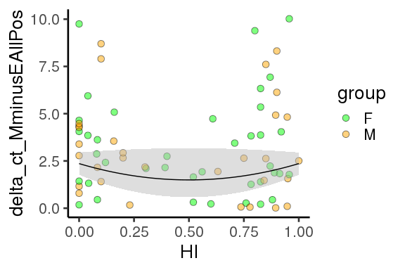

```r
plot_qpcr_student <- bananaPlots(mod = fit_qpcr_student$H0,
                                 data = qpcr_data[qpcr_data$delta_ct_MminusEAllPos > 0, ],
                                 response = "delta_ct_MminusEAllPos", group = "Sex")
plot_qpcr_student
```

## Part 2. OPG results, 4 hypotheses, difference between sexes

## Run the fit for load estimation along HI, negative binomial distribution

```r
fit_flotation_negbin <- analyse(flotation_data[flotation_data$OPG > 0, ],
                                   response = "OPG+1",
                                   model = "negbin", group = "Sex")
```

[output not shown]

[output cut: 40 more lines]

```
#> [1] "Testing H3 groupB no alpha vs alpha"
#>    dLL dDF pvalue
#> 1 1.02   1  0.154
#> [1] "Testing H1 vs H0"
#>   dLL dDF pvalue
#> 1   0   2 0.9993
#> [1] "Testing H2 vs H0"
#>    dLL dDF pvalue
#> 1 2.89   4 0.2155
#> [1] "Testing H3 vs H1"
#>    dLL dDF pvalue
#> 1 3.49   6 0.3235
#> [1] "Testing H3 vs H2"
#>    dLL dDF pvalue
#> 1 0.59   4 0.8806
```

```r
fit_flotation_negbin
```

```
#> $H0
#>
#> Call:
#> bbmle::mle2(minuslogl = response ~ dnbinom(mu = MeanLoad(L1,
#>     L1, alpha, HI), size = SizeNegBin(A1, A1, Z, HI)), start = start,
#>     method = config$method, optimizer = config$optimizer, data = data,
#>     lower = c(L1 = paramBounds[["L1LB"]], A1 = paramBounds[["A1LB"]],
#>         alpha = paramBounds[["alphaLB"]], Z = paramBounds[["ZLB"]]),
#>     upper = c(L1 = paramBounds[["L1UB"]], A1 = paramBounds[["A1UB"]],
#>         alpha = paramBounds[["alphaUB"]], Z = paramBounds[["ZUB"]]),
#>     control = config$control)
#>
#> Coefficients:
#>            L1         alpha            A1             Z
#>  4.105584e+04 -4.077911e-02  3.027997e+00  1.253127e+00
#>
#> Log-likelihood: -1077.87
#> Best method: L-BFGS-B
#>
#> $H1
#>
#> Call:
#> bbmle::mle2(minuslogl = response ~ dnbinom(mu = MeanLoad(L1,
#>     L2, alpha, HI), size = SizeNegBin(A1, A2, Z, HI)), start = start,
#>     method = config$method, optimizer = config$optimizer, data = data,
#>     lower = c(L1 = paramBounds[["L1LB"]], L2 = paramBounds[["L2LB"]],
#>         A1 = paramBounds[["A1LB"]], A2 = paramBounds[["A2LB"]],
#>         alpha = paramBounds[["alphaLB"]], Z = paramBounds[["ZLB"]]),
#>     upper = c(L1 = paramBounds[["L1UB"]], L2 = paramBounds[["L2UB"]],
#>         A1 = paramBounds[["A1UB"]], A2 = paramBounds[["A2UB"]],
#>         alpha = paramBounds[["alphaUB"]], Z = paramBounds[["ZUB"]]),
#>     control = config$control)
#>
#> Coefficients:
#>            L1            L2            A1            A2         alpha
#>  4.105584e+04  4.105584e+04  3.015471e+00  3.057202e+00 -3.832064e-02
#>             Z
#>  1.209010e+00
#>
#> Log-likelihood: -1077.87
```

[output cut: 73 more lines]

```
#>         A1 = paramBounds[["A1LB"]], A2 = paramBounds[["A2LB"]],
#>         alpha = paramBounds[["alphaLB"]], Z = paramBounds[["ZLB"]]),
#>     upper = c(L1 = paramBounds[["L1UB"]], L2 = paramBounds[["L2UB"]],
#>         A1 = paramBounds[["A1UB"]], A2 = paramBounds[["A2UB"]],
#>         alpha = paramBounds[["alphaUB"]], Z = paramBounds[["ZUB"]]),
#>     control = config$control)
#>
#> Coefficients:
#>            L1            L2            A1            A2         alpha
#> 41055.8397051 41055.8401578     2.3733499     3.8038523    -1.5972829
#>             Z
#>    -0.2503882
#>
#> Log-likelihood: -533.76
#> Best method: L-BFGS-B
```

```r
# bananaPlots(mod = fit_flotation_negbin$H0, data = flotation_data,
#             response = "OPG+1")
# problems for the profiling...
```

## Part 3. worms count, 4 hypotheses, difference between sexes

### Choose a correct distribution for our data : negative binomial see WATWM

### pinworms (A. tetraptera and S. obvelata (WATWMdata$Aspiculuris.Syphacia))

```r
fit_Joelle_negbin <- analyse(WATWMdata, "Aspiculuris.Syphacia+1",
                             model = "negbin", group = "Sex")
```

```
#> [1] "Analysing data for response: Aspiculuris.Syphacia+1"
#> [1] "Fit for the response: Aspiculuris.Syphacia+1"
#> [1] "Fitting for all"
#> [1] "Fitting model basic without alpha"
#> [1] "Did converge"
#> [1] "Fitting model basic with alpha"
#> [1] "Did converge"
#> [1] "Fitting model advanced without alpha"
#> [1] "Did converge"
#> [1] "Fitting model advanced with alpha"
#> [1] "Did converge"
#> [1] "Fitting for groupA : F"
#> [1] "Fitting model basic without alpha"
#> [1] "Did converge"
#> [1] "Fitting model basic with alpha"
```

[output cut: 44 more lines]

```r
fit_Joelle_negbin
```

```
#> $H0
#>
#> Call:
#> bbmle::mle2(minuslogl = response ~ dnbinom(mu = MeanLoad(L1,
#>     L1, alpha, HI), size = SizeNegBin(A1, A1, Z, HI)), start = start,
#>     method = config$method, optimizer = config$optimizer, data = data,
#>     lower = c(L1 = paramBounds[["L1LB"]], A1 = paramBounds[["A1LB"]],
#>         alpha = paramBounds[["alphaLB"]], Z = paramBounds[["ZLB"]]),
#>     upper = c(L1 = paramBounds[["L1UB"]], A1 = paramBounds[["A1UB"]],
#>         alpha = paramBounds[["alphaUB"]], Z = paramBounds[["ZUB"]]),
#>     control = config$control)
#>
#> Coefficients:
#>         L1      alpha         A1          Z
#> 53.8923557  1.3923721  2.4219621 -0.8069923
#>
#> Log-likelihood: -2914.96
#> Best method: L-BFGS-B
#>
#> $H1
#>
#> Call:
#> bbmle::mle2(minuslogl = response ~ dnbinom(mu = MeanLoad(L1,
#>     L2, alpha, HI), size = SizeNegBin(A1, A2, Z, HI)), start = start,
#>     method = config$method, optimizer = config$optimizer, data = data,
#>     lower = c(L1 = paramBounds[["L1LB"]], L2 = paramBounds[["L2LB"]],
#>         A1 = paramBounds[["A1LB"]], A2 = paramBounds[["A2LB"]],
#>         alpha = paramBounds[["alphaLB"]], Z = paramBounds[["ZLB"]]),
#>     upper = c(L1 = paramBounds[["L1UB"]], L2 = paramBounds[["L2UB"]],
#>         A1 = paramBounds[["A1UB"]], A2 = paramBounds[["A2UB"]],
#>         alpha = paramBounds[["alphaUB"]], Z = paramBounds[["ZUB"]]),
#>     control = config$control)
#>
#> Coefficients:
#>          L1          L2          A1          A2       alpha           Z
#> 73.16067147 34.89002447  2.45760891  2.02595977  1.33761290 -0.07863257
#>
#> Log-likelihood: -2902.01
#> Best method: L-BFGS-B
#>
```

[output cut: 67 more lines]

```
#>     method = config$method, optimizer = config$optimizer, data = data,
#>     lower = c(L1 = paramBounds[["L1LB"]], L2 = paramBounds[["L2LB"]],
#>         A1 = paramBounds[["A1LB"]], A2 = paramBounds[["A2LB"]],
#>         alpha = paramBounds[["alphaLB"]], Z = paramBounds[["ZLB"]]),
#>     upper = c(L1 = paramBounds[["L1UB"]], L2 = paramBounds[["L2UB"]],
#>         A1 = paramBounds[["A1UB"]], A2 = paramBounds[["A2UB"]],
#>         alpha = paramBounds[["alphaUB"]], Z = paramBounds[["ZUB"]]),
#>     control = config$control)
#>
#> Coefficients:
#>        L1        L2        A1        A2     alpha         Z
#> 68.865325 43.466548  2.564392  2.420666  1.399376 -1.234818
#>
#> Log-likelihood: -1399.11
#> Best method: L-BFGS-B
```

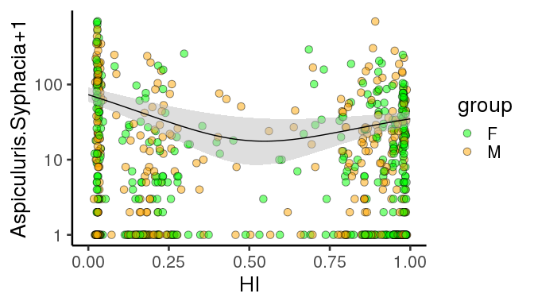

```r
plot_Joelle_negbin <- bananaPlots(mod = fit_Joelle_negbin$H1,
                                 data = WATWMdata,
                                 response = "Aspiculuris.Syphacia+1",
                                 islog10 = TRUE, group = "Sex")
plot_Joelle_negbin
```

### And Jennys now:

```r
fit_pinworms_negbin <- analyse(pinworms_data, "Aspiculuris.Syphacia+1",
                               model = "negbin", group = "Sex")
```

```
#> [1] "Analysing data for response: Aspiculuris.Syphacia+1"
#> [1] "Fit for the response: Aspiculuris.Syphacia+1"
#> [1] "Fitting for all"
#> [1] "Fitting model basic without alpha"
#> [1] "Did converge"
#> [1] "Fitting model basic with alpha"
#> [1] "Did converge"
#> [1] "Fitting model advanced without alpha"
#> [1] "Did converge"
#> [1] "Fitting model advanced with alpha"
#> [1] "Did converge"
#> [1] "Fitting for groupA : F"
#> [1] "Fitting model basic without alpha"
#> [1] "Did converge"
#> [1] "Fitting model basic with alpha"
```

[output cut: 44 more lines]

```r
fit_pinworms_negbin
```

```
#> $H0
#>
#> Call:
#> bbmle::mle2(minuslogl = response ~ dnbinom(mu = MeanLoad(L1,
#>     L1, alpha, HI), size = SizeNegBin(A1, A1, Z, HI)), start = start,
#>     method = config$method, optimizer = config$optimizer, data = data,
#>     lower = c(L1 = paramBounds[["L1LB"]], A1 = paramBounds[["A1LB"]],
#>         alpha = paramBounds[["alphaLB"]], Z = paramBounds[["ZLB"]]),
#>     upper = c(L1 = paramBounds[["L1UB"]], A1 = paramBounds[["A1UB"]],
#>         alpha = paramBounds[["alphaUB"]], Z = paramBounds[["ZUB"]]),
#>     control = config$control)
#>
#> Coefficients:
#>        L1     alpha        A1         Z
#> 26.665200  1.005523  2.699729 -1.165457
#>
#> Log-likelihood: -2244.39
#> Best method: L-BFGS-B
#>
#> $H1
#>
#> Call:
#> bbmle::mle2(minuslogl = response ~ dnbinom(mu = MeanLoad(L1,
#>     L2, alpha, HI), size = SizeNegBin(A1, A2, Z, HI)), start = start,
#>     method = config$method, optimizer = config$optimizer, data = data,
#>     lower = c(L1 = paramBounds[["L1LB"]], L2 = paramBounds[["L2LB"]],
#>         A1 = paramBounds[["A1LB"]], A2 = paramBounds[["A2LB"]],
#>         alpha = paramBounds[["alphaLB"]], Z = paramBounds[["ZLB"]]),
#>     upper = c(L1 = paramBounds[["L1UB"]], L2 = paramBounds[["L2UB"]],
#>         A1 = paramBounds[["A1UB"]], A2 = paramBounds[["A2UB"]],
#>         alpha = paramBounds[["alphaUB"]], Z = paramBounds[["ZUB"]]),
#>     control = config$control)
#>
#> Coefficients:
#>        L1        L2        A1        A2     alpha         Z
#> 17.284590 39.016932  2.474052  2.852781  1.201263 -1.334399
#>
#> Log-likelihood: -2232.44
#> Best method: L-BFGS-B
#>
```

[output cut: 67 more lines]

```
#>     method = config$method, optimizer = config$optimizer, data = data,
#>     lower = c(L1 = paramBounds[["L1LB"]], L2 = paramBounds[["L2LB"]],
#>         A1 = paramBounds[["A1LB"]], A2 = paramBounds[["A2LB"]],
#>         alpha = paramBounds[["alphaLB"]], Z = paramBounds[["ZLB"]]),
#>     upper = c(L1 = paramBounds[["L1UB"]], L2 = paramBounds[["L2UB"]],
#>         A1 = paramBounds[["A1UB"]], A2 = paramBounds[["A2UB"]],
#>         alpha = paramBounds[["alphaUB"]], Z = paramBounds[["ZUB"]]),
#>     control = config$control)
#>
#> Coefficients:
#>        L1        L2        A1        A2     alpha         Z
#> 16.959850 35.665309  2.612965  2.828801  1.475959 -2.454769
#>
#> Log-likelihood: -986.86
#> Best method: L-BFGS-B
```

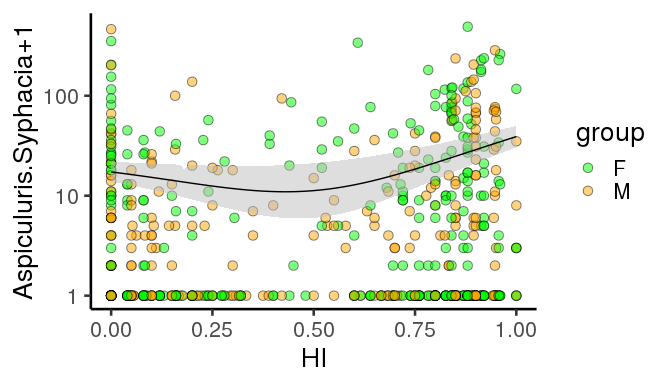

```r
plot_pinworms_negbin <- bananaPlots(mod = fit_pinworms_negbin$H1,
                                  data = pinworms_data,
                                  response = "Aspiculuris.Syphacia+1",
                                  islog10 = TRUE, group = "Sex")
plot_pinworms_negbin
```

## qPCR vs worms (is there a correlation?)

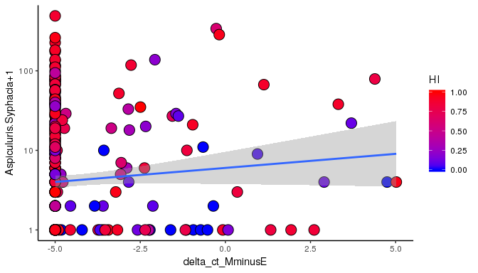

```r
ggplot2::ggplot(pinworms_data,
       aes(delta_ct_MminusE, `Aspiculuris.Syphacia+1`)) +
  geom_point(aes(fill = HI), pch = 21, size = 5) +
  scale_fill_gradient(low = "blue", high = "red") +
  scale_y_log10() +
  geom_smooth(method = "lm") +
  theme_classic()
```

```r
summary(lm(`Aspiculuris.Syphacia+1` ~ delta_ct_MminusE, data = BALdata))
```

```
#>
#> Call:
#> lm(formula = `Aspiculuris.Syphacia+1` ~ delta_ct_MminusE, data = BALdata)
#>
#> Residuals:
#>    Min     1Q Median     3Q    Max
#> -36.02 -16.48 -15.48  -4.98 472.52
#>
#> Coefficients:
#>                  Estimate Std. Error t value Pr(>|t|)
#> (Intercept)        28.726      6.821   4.211  3.2e-05 ***
#> delta_ct_MminusE    2.249      1.451   1.550    0.122
#> ---
#> Signif. codes:  0 '***' 0.001 '**' 0.01 '*' 0.05 '.' 0.1 ' ' 1
#>
#> Residual standard error: 46.55 on 369 degrees of freedom
#>   (284 observations deleted due to missingness)
#> Multiple R-squared:  0.006473,   Adjusted R-squared:  0.00378
#> F-statistic: 2.404 on 1 and 369 DF,  p-value: 0.1219
```

## Part 4. body data, 4 hypotheses, difference between infected/not infected

### TO DO : test coinfection data!! Are coinfected individuals more suffering?

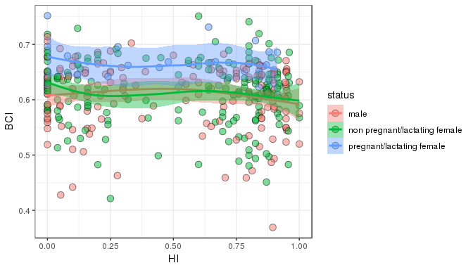

```r
body_data$status[body_data$Sex %in% c("F")] <- "non pregnant/lactating female"
body_data$status[body_data$Status %in% c("post partum", "post partum (lactating)", "pregnant")] <- "pregnant/lactating female"
body_data$status[body_data$Sex %in% c("M")] <- "male"

# Test  our detection of pregnancy in females using BCI
ggplot2::ggplot(body_data,
       ggplot2::aes(x = HI, y = BCI, fill = status, group = status)) +
  geom_point(pch = 21, size = 3, alpha = .5)+
  geom_smooth(aes(col = status)) +
  theme_bw()
```

```r
# Remove pregnant females
body_data <- body_data[!body_data$status %in% c("pregnant/lactating female"), ]
```

- Step 1: fit the model

```r
fitRes <- lm(Body_weight ~ Body_length * Sex, data = body_data)
```

- Step 2: obtain predicted and residual values

```r
body_data$predicted <- predict(fitRes)   # Save the predicted values
body_data$residuals <- residuals(fitRes) # Save the residual values
```

- Step 3: plot the actual and predicted values

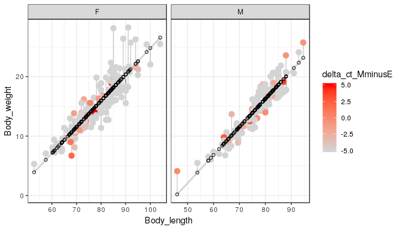

```r
ggplot2::ggplot(body_data, ggplot2::aes(x = Body_length, y = Body_weight)) +
  ggplot2::geom_smooth(method = "lm", se = FALSE, color = "lightgrey") +  # Plot regression slope
  ggplot2::geom_segment(ggplot2::aes(xend = Body_length, yend = predicted), alpha = .2) +  # alpha to fade lines
  ggplot2::geom_point(ggplot2::aes(col = delta_ct_MminusE), size = 3) +
  ggplot2::scale_color_gradient(low = "lightgrey", high = "red") +
  ggplot2::geom_point(ggplot2::aes(y = predicted), shape = 1) +
  ggplot2::facet_grid(~ Sex, scales = "free_x") +  # Split panels here by `iv`
  ggplot2::theme_bw()  # Add theme for cleaner look
```

- Step 4: use residuals as indice

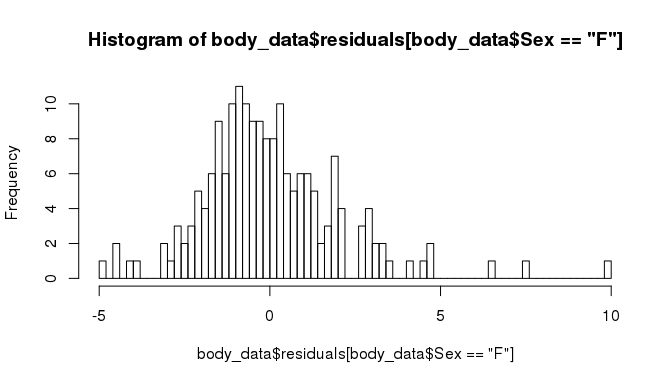

```r
hist(body_data$residuals[body_data$Sex =="F"], breaks = 100) # remove outliers, keep [-5,5] interval
```

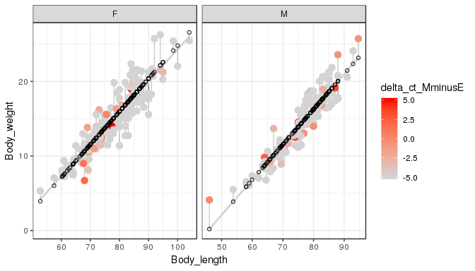

```r
body_data <- body_data[body_data$residuals <= 5,]
body_data$resBMBL <- body_data$residuals

# give positive values only
body_data$resBMBL <- body_data$resBMBL + 5

# Plot the actual and predicted values
ggplot2::ggplot(body_data, ggplot2::aes(x = Body_length, y = Body_weight)) +
  ggplot2::geom_smooth(method = "lm", se = FALSE, color = "lightgrey") +  # Plot regression slope
  ggplot2::geom_segment(ggplot2::aes(xend = Body_length, yend = predicted), alpha = .2) +  # alpha to fade lines
  ggplot2::geom_point(ggplot2::aes(col = delta_ct_MminusE), size = 3) +
  ggplot2::scale_color_gradient(low = "lightgrey", high = "red") +
  ggplot2::geom_point(ggplot2::aes(y = predicted), shape = 1) +
  ggplot2::facet_grid(~ Sex, scales = "free_x") +  # Split panels here by `iv`
  ggplot2::theme_bw()  # Add theme for cleaner look
```

### Which distribution to choose?

Let’s compute some fits…

```r
fits <- list(
  normal = MASS::fitdistr(body_data$resBMBL,"normal"),
  student = MASS::fitdistr(body_data$resBMBL, "t",
                     start = list(m = mean(body_data$resBMBL),
                                  s = sd(body_data$resBMBL), df = 3),
                     lower=c(-1, 0.001,1))
)
# get the logliks for each model...
sapply(fits, function(i) i$loglik)
```

```
#>    normal   student
#> -641.8484 -639.6178
```

STUDENT is the way to go!

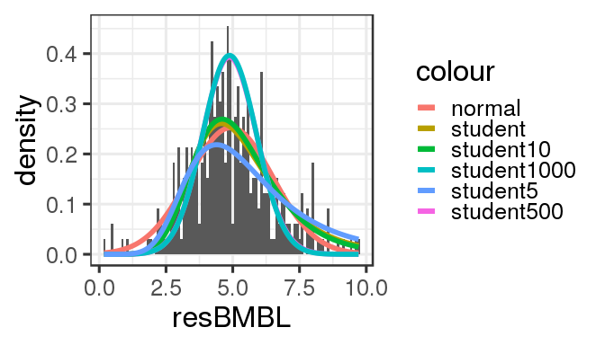

```r
ggplot2::ggplot(body_data, ggplot2::aes(resBMBL)) +
  ggplot2::geom_histogram(ggplot2::aes(y=..density..), bins = 100) +
  ggplot2::stat_function(fun = dnorm, n = 1e3, args = list(mean = fits$normal$estimate[1], sd = fits$normal$estimate[2]),
                ggplot2::aes(color = "normal"), size = 2) +
  ggplot2::stat_function(fun = dt, n = 1e3, args = list(ncp = fits$student$estimate[1],
                                               df = fits$student$estimate[3]),
                ggplot2::aes(color = "student"), size = 2) +
  ggplot2::stat_function(fun = dt, n = 1e3, args = list(ncp = fits$student$estimate[1],
                                               df = 10),
                ggplot2::aes(color = "student10"), size = 2) +
  ggplot2::stat_function(fun = dt, n = 1e3, args = list(ncp = fits$student$estimate[1],
                                               df = 400),
                ggplot2::aes(color = "student500"), size = 2) +
  ggplot2::stat_function(fun = dt, n = 1e3, args = list(ncp = fits$student$estimate[1],
                                               df = 1000),
                ggplot2::aes(color = "student1000"), size = 2) +
  ggplot2::stat_function(fun = dt, n = 1e3, args = list(ncp = fits$student$estimate[1],
                                               df = 5),
                ggplot2::aes(color = "student5"), size = 2) +
  ggplot2::theme_bw(base_size = 24)
```

### Fit the model!

```r
fit_body_student <- analyse(body_data, response = "resBMBL",
                            model = "student", group = "qPCRstatus")
```

[output not shown]

[output cut: 40 more lines]

```
#> [1] "Testing H3 groupB no alpha vs alpha"
#>    dLL dDF pvalue
#> 1 0.55   1 0.2934
#> [1] "Testing H1 vs H0"
#>     dLL dDF pvalue
#> 1 11.72   1      0
#> [1] "Testing H2 vs H0"
#>    dLL dDF pvalue
#> 1 0.29   3 0.9022
#> [1] "Testing H3 vs H1"
#>    dLL dDF pvalue
#> 1 0.31   4 0.9617
#> [1] "Testing H3 vs H2"
#>     dLL dDF pvalue
#> 1 11.74   2      0
```

```r
fit_body_student
```

```
#> $H0
#>
#> Call:
#> bbmle::mle2(minuslogl = response ~ dt(ncp = MeanLoad(L1, L1,
#>     alpha, HI), df = mydf), start = start, method = config$method,
#>     optimizer = config$optimizer, data = data, lower = c(L1 = paramBounds[["L1LB"]],
#>         alpha = paramBounds[["alphaLB"]], mydf = paramBounds[["mydfLB"]]),
#>     upper = c(L1 = paramBounds[["L1UB"]], alpha = paramBounds[["alphaUB"]],
#>         mydf = paramBounds[["mydfUB"]]), control = config$control)
#>
#> Coefficients:
#>          L1       alpha        mydf
#>  4.56449277  0.01157639 10.00000000
#>
#> Log-likelihood: -651.53
#> Best method: L-BFGS-B
#>
#> $H1
#>
#> Call:
#> bbmle::mle2(minuslogl = response ~ dt(ncp = MeanLoad(L1, L2,
#>     alpha, HI), df = mydf), start = start, method = config$method,
#>     optimizer = config$optimizer, data = data, lower = c(L1 = paramBounds[["L1LB"]],
#>         L2 = paramBounds[["L2LB"]], alpha = paramBounds[["alphaLB"]],
#>         mydf = paramBounds[["mydfLB"]]), upper = c(L1 = paramBounds[["L1UB"]],
#>         L2 = paramBounds[["L2UB"]], alpha = paramBounds[["alphaUB"]],
#>         mydf = paramBounds[["mydfUB"]]), control = config$control)
#>
#> Coefficients:
#>         L1         L2      alpha       mydf
#>  4.9772206  3.9090282 -0.1464907 10.0000000
#>
#> Log-likelihood: -639.81
#> Best method: L-BFGS-B
#>
#> $H2
#> $H2$groupA
#>
#> Call:
#> bbmle::mle2(minuslogl = response ~ dt(ncp = MeanLoad(L1, L1,
```

[output cut: 52 more lines]

```
#> Call:
#> bbmle::mle2(minuslogl = response ~ dt(ncp = MeanLoad(L1, L2,
#>     alpha, HI), df = mydf), start = start, method = config$method,
#>     optimizer = config$optimizer, data = data, lower = c(L1 = paramBounds[["L1LB"]],
#>         L2 = paramBounds[["L2LB"]], alpha = paramBounds[["alphaLB"]],
#>         mydf = paramBounds[["mydfLB"]]), upper = c(L1 = paramBounds[["L1UB"]],
#>         L2 = paramBounds[["L2UB"]], alpha = paramBounds[["alphaUB"]],
#>         mydf = paramBounds[["mydfUB"]]), control = config$control)
#>
#> Coefficients:
#>         L1         L2      alpha       mydf
#>  4.9404445  3.8565208 -0.2872107 10.0000000
#>
#> Log-likelihood: -125.38
#> Best method: L-BFGS-B
```

```r
# bananaPlots(mod = fit_body_student$H1, data = body_data, response = "resBMBL")
#
# bananaPlots(mod = fit_body_student$H3, data = body_data, response = "resBMBL", group = "qPCRstatus")
```

# Suggestion from Stuart

Sounds very cool. You may well have thought of this, but anyway (because likelihood is lovely)… a nice zonewise pinworm comparison is as follows:

Do whole analysis on combined {WATWM, Jenny’s} data -> Joint LLsurface You already have the whole analyses on the zonewise-split of this joint data. -> {WATM LL surface,Jenny LL surface} … and off we go: compare Max(WATWM LL surface)+Max(Jenny LL surface) VS Max(Joint LLsurface)

On either side of the VS the same data is analysed - so LL comparison is valid. Any ‘is there really a difference between the two zones re pinworms’ style of question reduces to: Force them to be the same (the joint analysis) VS allow them to be different (WATWM and Jenny’s each have their own parameters)…. once you have counted degrees of freedom you can look up the answer to any such question in a ChiSquared table… its so sweeeet! (ok… there are lots of axes of heterogeneity… it not quite so simple as all that - but its basically what you do already re eg comparison of sexes)

```r
fit_allWorms_negbin <- analyse(allWorms, "Aspiculuris.Syphacia+1",
                               model = "negbin", group = "batch")
```

```
#> [1] "Analysing data for response: Aspiculuris.Syphacia+1"
#> [1] "Fit for the response: Aspiculuris.Syphacia+1"
#> [1] "Fitting for all"
#> [1] "Fitting model basic without alpha"
#> [1] "Did converge"
#> [1] "Fitting model basic with alpha"
#> [1] "Did converge"
#> [1] "Fitting model advanced without alpha"
#> [1] "Did converge"
#> [1] "Fitting model advanced with alpha"
#> [1] "Did converge"
#> [1] "Fitting for groupA : JENNY"
#> [1] "Fitting model basic without alpha"
#> [1] "Did converge"
#> [1] "Fitting model basic with alpha"
```

[output cut: 44 more lines]

```r
fit_allWorms_negbin
```

```
#> $H0
#>
#> Call:
#> bbmle::mle2(minuslogl = response ~ dnbinom(mu = MeanLoad(L1,
#>     L1, alpha, HI), size = SizeNegBin(A1, A1, Z, HI)), start = start,
#>     method = config$method, optimizer = config$optimizer, data = data,
#>     lower = c(L1 = paramBounds[["L1LB"]], A1 = paramBounds[["A1LB"]],
#>         alpha = paramBounds[["alphaLB"]], Z = paramBounds[["ZLB"]]),
#>     upper = c(L1 = paramBounds[["L1UB"]], A1 = paramBounds[["A1UB"]],
#>         alpha = paramBounds[["alphaUB"]], Z = paramBounds[["ZUB"]]),
#>     control = config$control)
#>
#> Coefficients:
#>        L1     alpha        A1         Z
#> 42.277719  1.342483  2.617645 -1.030950
#>
#> Log-likelihood: -5181.32
#> Best method: L-BFGS-B
#>
#> $H1
#>
#> Call:
#> bbmle::mle2(minuslogl = response ~ dnbinom(mu = MeanLoad(L1,
#>     L2, alpha, HI), size = SizeNegBin(A1, A2, Z, HI)), start = start,
#>     method = config$method, optimizer = config$optimizer, data = data,
#>     lower = c(L1 = paramBounds[["L1LB"]], L2 = paramBounds[["L2LB"]],
#>         A1 = paramBounds[["A1LB"]], A2 = paramBounds[["A2LB"]],
#>         alpha = paramBounds[["alphaLB"]], Z = paramBounds[["ZLB"]]),
#>     upper = c(L1 = paramBounds[["L1UB"]], L2 = paramBounds[["L2UB"]],
#>         A1 = paramBounds[["A1UB"]], A2 = paramBounds[["A2UB"]],
#>         alpha = paramBounds[["alphaUB"]], Z = paramBounds[["ZUB"]]),
#>     control = config$control)
#>
#> Coefficients:
#>         L1         L2         A1         A2      alpha          Z
#> 46.5702673 37.4547284  2.7784168  2.3435744  1.3115956 -0.7406972
#>
#> Log-likelihood: -5177.61
#> Best method: L-BFGS-B
#>
```

[output cut: 67 more lines]

```
#>     method = config$method, optimizer = config$optimizer, data = data,
#>     lower = c(L1 = paramBounds[["L1LB"]], L2 = paramBounds[["L2LB"]],
#>         A1 = paramBounds[["A1LB"]], A2 = paramBounds[["A2LB"]],
#>         alpha = paramBounds[["alphaLB"]], Z = paramBounds[["ZLB"]]),
#>     upper = c(L1 = paramBounds[["L1UB"]], L2 = paramBounds[["L2UB"]],
#>         A1 = paramBounds[["A1UB"]], A2 = paramBounds[["A2UB"]],
#>         alpha = paramBounds[["alphaUB"]], Z = paramBounds[["ZUB"]]),
#>     control = config$control)
#>
#> Coefficients:
#>         L1         L2         A1         A2      alpha          Z
#> 73.1616012 34.8895673  2.4577597  2.0260878  1.3377790 -0.0791076
#>
#> Log-likelihood: -2902.01
#> Best method: L-BFGS-B
```

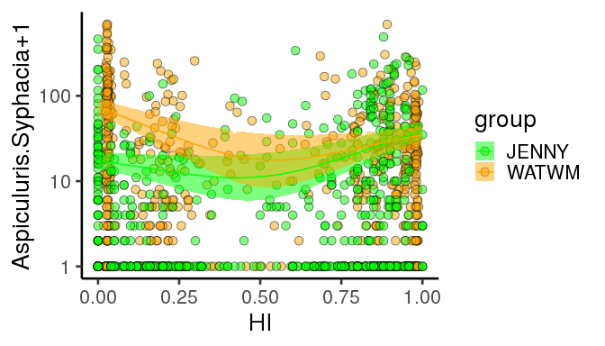

```r
bananaPlots(data = allWorms, response = "Aspiculuris.Syphacia+1",
            mod = fit_allWorms_negbin$H3,
            group = "batch", islog10 = T)
```

```r
bananaPlots
```

```
#> function(mod, data, response, hybridIndex = seq(0,1, 0.01),
#>                         cols = c("green", "orange"), group, islog10 = F){
#>   # for aes_string
#>   data$response = data[[response]]
#>   data$group = data[[group]]
#>   if(is.list(mod) == FALSE){ # we do not have differences between groups
#>     bananaDF = getBananaDF(mod, hybridIndex)
#>     # Draw the line for the parameters at their MLE, alpha varying
#>     ggplot2::ggplot() +
#>       ggplot2::geom_point(data = data, ggplot2::aes_string(x = "HI", y = "response", fill = "group"),
#>                           pch = 21, size = 3, alpha = .5) +
#>       ggplot2::geom_ribbon(data = bananaDF,
#>                            ggplot2::aes_string(x = "HI", ymin = "min", ymax = "max"),
#>                            fill = "grey", alpha = .5) +
#>       ggplot2::geom_line(data = bananaDF,
#>                          ggplot2::aes_string(x = "HI", y = "fit")) +
#>       ggplot2::scale_fill_manual(values = cols) +
#>       ggplot2::theme_classic(base_size = 20) + {
#>         if(islog10 == TRUE) ggplot2::scale_y_log10()
#>       } +
#>       ggplot2::ylab(label = response)
#>   }else{
#>     bananaDF = data.frame(HI = numeric(), fit = numeric(), min = numeric(), max = numeric(), group = factor())
#>     mygroupDFnames = vector()
#>     for (n in names(mod)){
#>       thisbanana = getBananaDF(mod[[n]], hybridIndex)
#>       thisbanana$group <- n
#>       bananaDF <- rbind(bananaDF, thisbanana)
#>     }
#>     bananaDF$group[bananaDF$group == "groupA"] <- levels(data$group)[1]
#>     bananaDF$group[bananaDF$group == "groupB"] <- levels(data$group)[2]
#>     # Draw the line for the parameters at their MLE, alpha varying
#>     ggplot2::ggplot()+
#>       ggplot2::geom_point(data = data, ggplot2::aes_string(x = "HI", y = "response", fill = "group"),
#>                           pch = 21, size = 3, alpha = .5) +
#>       ggplot2::geom_ribbon(data = bananaDF,
#>                            ggplot2::aes_string(x = "HI", ymin = "min", ymax = "max",
#>                                                fill = "group"), alpha = .5) +
#>       ggplot2::geom_line(data = bananaDF,
#>                          ggplot2::aes_string(x = "HI", y = "fit", col = "group")) +
#>       ggplot2::scale_fill_manual(values = cols) +
#>       ggplot2::scale_color_manual(values = cols) +
#>       ggplot2::theme_classic(base_size = 20) + {
#>         if(islog10 == TRUE) ggplot2::scale_y_log10()
#>       } +
#>       ggplot2::ylab(label = response)
#>   }
#> }
#> <bytecode: 0x8d7cd80>
```